# act_report

## Report: act_report

```python
import pandas as pd
import seaborn as sns
import matplotlib.pyplot as plt
%matplotlib inline
```

```python
tw_archive_clean = pd.read_csv('twitter_archive_master.csv')
```

#### Top Dog Names

One of the great things that WeRateDogs does is to bring attention to dogs who may not fit the traditional thoughts people have about what makes a good dog. There is a meme that has been going around the internet for a while that sums up their goal perfectly: "They're good dogs Brent." This meme actually originated when another user, @brant, questioned they're rating system on Twitter. We were able to maintain the integrity of their particular rating system, while cleaning up the data that was pulled from their twitter feed.

The below visualizations represent several insights I was able to pull from the available data.

1. The most represented dog names in their tweets are Charlie and Lucy. I'm a fan of human names for dogs and I think this proves that a lot of other people are as well.
2. The breed with the most mentions is the Golden Retriever. This seems to fit expectations as it is an extremely popular breed.
3. I wanted to also show the disbursement of ratings as it pertains to particular breeds. This was a good look into the range of ratings and the ability to see any breed-specific trends.
4. I also looked at the same rating disbursement but how it pertains to stage. This was clear that the Floofer stage has the most consistent high ratings of the four stages.
5. Lastly, I wanted to see how the retweet and favorite counts looked when taking breed into account. There isn't a huge correlation, but it does appear that certain breeds tend to have higher rates of favoriting and retweeting.

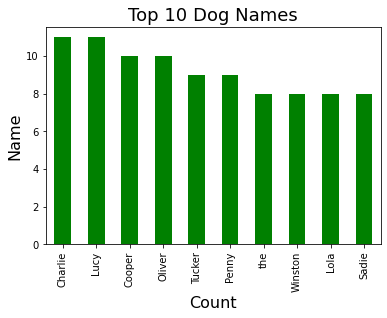

```python
# Bar chart displaying the top 10 dog names
top_dog_name = tw_archive_clean.name.value_counts()[0:10].sort_values(axis=0, ascending=False)
top_dog_name.plot(kind = 'bar', color=['Green'])
plt.title('Top 10 Dog Names', size=18)
plt.xlabel('Count', size=16)
plt.ylabel('Name', size=16)
plt.savefig('top-names.png');
```

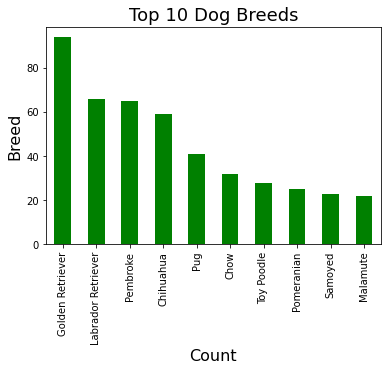

```python
# Bar chart displaying the top 10 dog breeds
top_dog_breed = tw_archive_clean.breed.value_counts()[0:10].sort_values(axis=0, ascending=False)
top_dog_breed.plot(kind = 'bar', color = ['Green'])
plt.title('Top 10 Dog Breeds', size=18)
plt.xlabel('Count', size=16)
plt.ylabel('Breed', size=16)
plt.savefig('top-breeds.png');
```

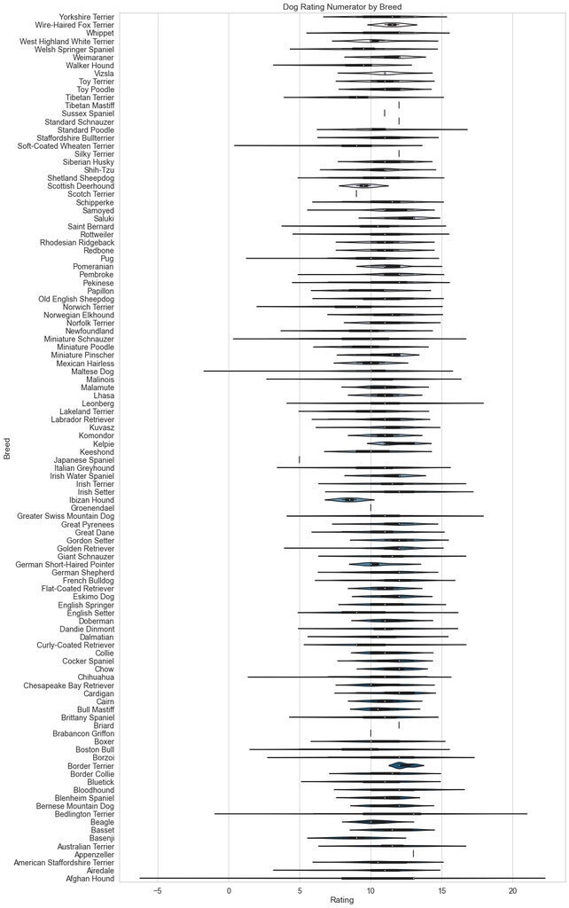

```python
# violin chart showing the distribution of ratings by breed.
# I thought this would be an interesting look at the rating disbursement.

sns.set(rc={'figure.figsize':(15,30)}, font_scale=1.3)

temp_df = tw_archive_clean[['breed', 'rating_numerator']]

my_order = tw_archive_clean.groupby(by=["breed"])["rating_numerator"].median().iloc[::-1].index


sns.set_style("whitegrid")
ax = sns.violinplot(x = temp_df.rating_numerator,
                    y = temp_df.breed,
                    orient ="h",
                    palette = "PuBu",
                    order = my_order)

ax.set(xlabel='Rating',
       ylabel='Breed',
       title = 'Dog Rating Numerator by Breed')

plt.show()
```

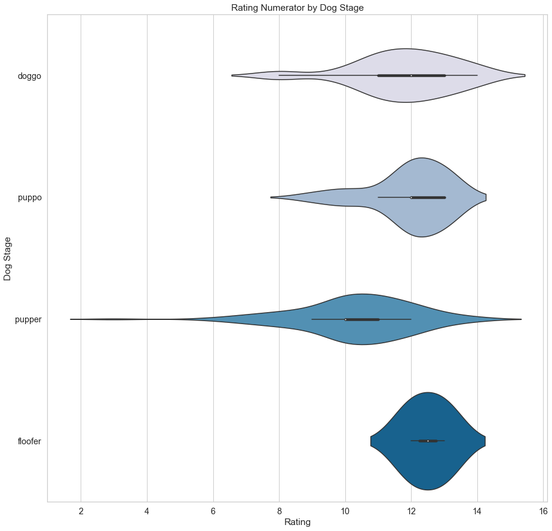

```python
# violin chart showing the distribution of ratings by dog stage
# This one is more striking because of the fewer categories to compare

sns.set(rc={'figure.figsize':(15,15)}, font_scale=1.3)

temp_df = tw_archive_clean[["rating_numerator", "dog_stage"]]


sns.set_style("whitegrid")
ax = sns.violinplot(x = temp_df.rating_numerator,
                    y = temp_df.dog_stage,
                    orient ="h",
                    palette = "PuBu")

ax.set(xlabel='Rating',
       ylabel='Dog Stage',
       title = 'Rating Numerator by Dog Stage')

plt.show()
```

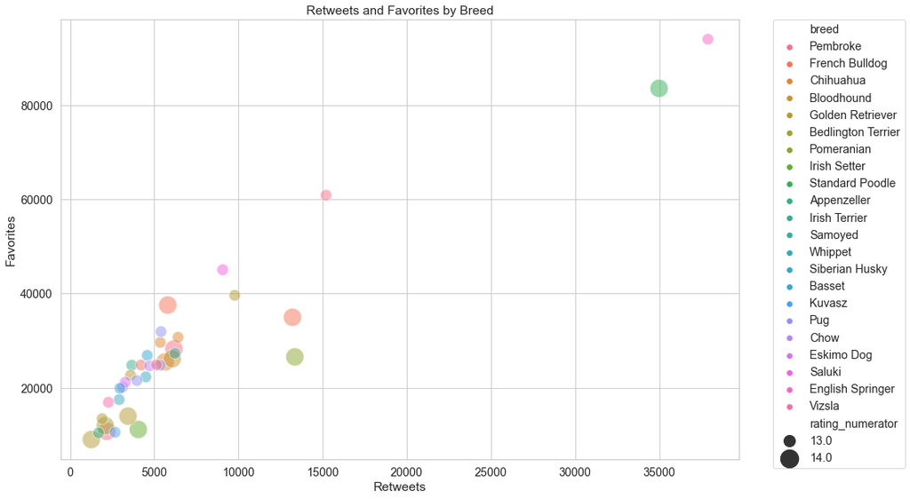

```python
# This scatterplot is showing the retweets and favorites for each breed based on
# rating_numerator.

# set chart dimension
plt.figure(figsize=(15,10))

# set plotting style and source
sns.set_style('whitegrid')
sns.scatterplot(data = tw_archive_clean.nlargest(50, 'rating_numerator'),
                x = "retweet_count",
                y = "favorite_count",
                hue = "breed",
                size = 'rating_numerator',
                sizes = (200, 500),
                alpha = 0.5)

# set title and labels
plt.title('Retweets and Favorites by Breed')
plt.xlabel('Retweets')
plt.ylabel('Favorites')

# move the legend outside the chart
plt.legend(bbox_to_anchor=(1.05, 1), loc='upper left', borderaxespad=0.);
```